# README

## scDesign3

The R package **scDesign3** is an all-in-one single-cell data simulation tool by using reference datasets with different cell states (cell types, trajectories or and spatial coordinates), different modalities (gene expression, chromatin accessibility, protein abundance, DNA methylation,etc), and complex experimental designs. The transparent parameters enable users to alter models as needed; the model evaluation metrics (AIC, BIC) and convenient visualization function help users select models. The following illustration figure summarizes the usage of scDesign3:

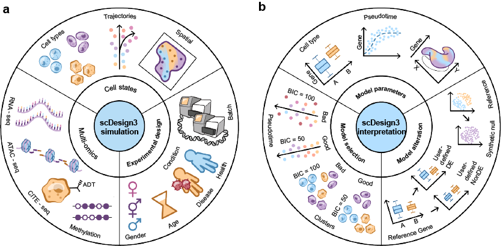

To find out more details about **scDesign3**, you can check out our preprint on BioRxiv:

[Song, D., Wang, Q., Yan, G., Liu, T., & Li, J. J. (2022). A unified framework of realistic in silico data generation and statistical model inference for single-cell and spatial omics. *bioRxiv*.](https://www.biorxiv.org/content/10.1101/2022.09.20.508796v2)

## Installation

To install the development version from github, please run:

```r
if (!require("devtools", quietly = TRUE))
    install.packages("devtools")
devtools::install_github("SONGDONGYUAN1994/scDesign3")
```

We are now working on submitting it to Bioconductor, and will provide the link once online.

## Quick Start

The following code is an quick example for running our simulator. The function `scdesign3()` takes in a `SinglecellExperiment` object with the cell covariates(such as cell types, pesudotime, or spatial coordinates) stored in the `colData` of the `SinglecellExperiment` object. For more details of the `SinlgeCellExperiment` object, please check on its [Bioconductor link](https://bioconductor.org/packages/release/bioc/html/SingleCellExperiment.html).

```r
example_simu <- scdesign3(
    sce = example_sce,
    assay_use = "counts",
    celltype = "cell_type",
    pseudotime = "pseudotime",
    spatial = NULL,
    other_covariates = NULL,
    mu_formula = "s(pseudotime, k = 10, bs = 'cr')",
    sigma_formula = "s(pseudotime, k = 5, bs = 'cr')",
    family_use = "nb",
    n_cores = 2,
    usebam = FALSE,
    corr_formula = "1",
    copula = "gaussian",
    DT = TRUE,
    pseudo_obs = FALSE,
    return_model = FALSE,
    nonzerovar = FALSE
  )
```

The output of `scdesign3()` is a list which includes:

- `new_count`: This is the synthetic count matrix generated by `scdesign3()`.
- `new_covariate`:
  - If the parameter `ncell` is set to a number that is different from the number of cells in the input data, this will be a matrix that has the new cell covariates that are used for generating new data.
  - If the parameter `ncell` is the default value, this will be `NULL`.
- `model_aic`: This is a vector include the genes’ marginal models’ AIC, fitted copula’s AIC, and total AIC, which is the sum of the previous two.
- `model_bic`: This is a vector include the genes’ marginal models’ BIC, fitted copula’s BIC, and total BIC, which is the sum of the previous two.
- `marginal_list`:
  - If the parameter `return_model` is set to `TRUE`, this will be a list which contains the fitted gam or gamlss model for all genes in the input data. This may greatly increase the object size.
  - If the parameter `return_model` is set to the default value `FALSE`, this will be `NULL`.
- `corr_list`:
  - If the parameter `return_model` is set to `TRUE`, this will be a list which contains either a correlation matrix (when `copula = "gaussian"`) or the fitted Vine copula (when `copula = "vine`) for each user specified correlation groups (based on the parameter `corr_by`).
  - If the parameter `return_model` is set to the default value `FALSE`, this will be `NULL`.

## Tutorials

For all detailed tutorials, please check the [website](https://songdongyuan1994.github.io/scDesign3/docs/index.html). The tutorials will demonstrate the applications of **scDesign3** from the following four perspectives: data simulation, model parameters, model selection, and model alteration.

- Data simulation
  - scDesign3 introduction
  - Simulate datasets with multiple lineages
  - Simulate spatial transcriptomic data
  - Simulate single-cell ATAC-seq data
  - Simulate CITE-seq data
  - Simulate multi-omics data from multiple single-omic datasets
  - Simulate datasets with batch effect
  - Simulate datasets with condition effect
- Model parameter
  - scDesign3 introduction
  - Compare Gaussian copula and Vine copula
- Model selection
  - Evaluate clustering goodness-of-fit by scDesign3
  - Evaluate pseudotime goodness-of-fit by scDesign3
- Model alteration
  - Simulate datasets with batch effect
  - Simulate datasets with condition effect
  - Simulate datasets for DE test

## Contact

Any questions or suggestions on `scDesign3` are welcomed! Please report it on issues, or contact Dongyuan Song (dongyuansong@ucla.edu) or Qingyang Wang (qw802@g.ucla.edu).

## Related Manuscripts

- The predecessors of **scDesign3**
  - **scDesign**: [Li, W. V., & Li, J. J. (2019). A statistical simulator scDesign for rational scRNA-seq experimental design. Bioinformatics, 35(14), i41-i50.](https://academic.oup.com/bioinformatics/article/35/14/i41/5529133)
  - **scDesign2**: [Sun, T., Song, D., Li, W. V., & Li, J. J. (2021). scDesign2: a transparent simulator that generates high-fidelity single-cell gene expression count data with gene correlations captured. Genome biology, 22(1), 1-37.](https://link.springer.com/article/10.1186/s13059-021-02367-2)
- The simulator for single-cell multi-omics reads developed by our lab memeber Guanao Yan
  - **scReadSim**: [Yan, G., & Li, J. J. (2022). scReadSim: a single-cell multi-omics read simulator. bioRxiv.](https://www.biorxiv.org/content/10.1101/2022.05.29.493924v1.abstract)